# KC_Roasters_Full_code_notebook

## Problem Statement

### Business Context

Coffee roasting is the process of turning green coffee beans into brown ones. Brown coffee beans can be made in a variety of methods, which also influences the flavor of the end product. A roasting instrument is basically a convection oven. It is a mechanism of inflicting heat energy into the raw product which makes the product consumable. And the price of coffee is heavily influenced by the quality of the beans after roasting. As a result, the cost can be determined depending on the quality of the beans after roasting.

The rising automation in the manufacturing business necessitates the automation of quality inspection of output products with minimal human intervention. Quality inspectors in businesses examine product quality after it is manufactured to ensure that it meets industry standards.

Each product's quality inspection is a time-consuming manual process, and a low-quality product wastes upstream factory capacity, consumables, labor, and money. With the emerging AI trend, companies are looking to leverage machine learning-based technologies to automate material quality inspection during the manufacturing process to reduce human intervention while achieving human-level or better accuracy.

### Objective

A roasting corporation named "KC Roasters" has engaged you to predict the quality of a roasting instrument's outputs, which will be used to determine the price of coffee beans. The quality value ranges from 0 to 100 with 0 being the worst and 100 being the best. and the higher the quality of the beans, the higher the price.

The coffee roasting instrument used by Roasters is divided into five equal-sized compartments, each with three temperature sensors. 3 sensors have been installed at 3 different locations to be able to capture temperature at different locations inside the chamber. Additionally, the height of raw material (volume entering the chamber) and relative humidity of roasted material is provided

The data shared consists of 17 predictor variables and a continuous target variable, and the aim is to build a Regression model which can accurately predict the quality of the product. After finding out the quality, the company can decide the cost of beans effectively.

### Data Dictionary

- T_data_1_1 - Temperature recorded by 1st sensor in the 1st chamber in Fahrenheit
- T_data_1_2 - Temperature recorded by 2nd sensor in the 1st chamber in Fahrenheit
- T_data_1_3 - Temperature recorded by 3rd sensor in the 1st chamber in Fahrenheit
- T_data_2_1 - Temperature recorded by 1st sensor in the 2nd chamber in Fahrenheit
- T_data_2_2 - Temperature recorded by 2nd sensor in the 2nd chamber in Fahrenheit
- T_data_2_3 - Temperature recorded by 3rd sensor in the 2nd chamber in Fahrenheit
- T_data_3_1 - Temperature recorded by 1st sensor in the 3rd chamber in Fahrenheit
- T_data_3_2 - Temperature recorded by 2nd sensor in the 3rd chamber in Fahrenheit
- T_data_3_3 - Temperature recorded by 3rd sensor in the 3rd chamber in Fahrenheit
- T_data_4_1 - Temperature recorded by 1st sensor in the 4th chamber in Fahrenheit
- T_data_4_2 - Temperature recorded by 2nd sensor in the 4th chamber in Fahrenheit
- T_data_4_3 - Temperature recorded by 3rd sensor in the 4th chamber in Fahrenheit
- T_data_5_1 - Temperature recorded by 1st sensor in the 5th chamber in Fahrenheit
- T_data_5_2 - Temperature recorded by 2nd sensor in the 5th chamber in Fahrenheit
- T_data_5_3 - Temperature recorded by 3rd sensor in the 5th chamber in Fahrenheit
- H_data - Height of Raw material layer, basically represents the volume of raw material going inside the chamber in pounds.
- AH_data - Roasted Coffee beans relative humidity.
- quality - Quality of the beans

## Importing necessary libraries

```python
#Libraries to help with reading and manipulating data
import pandas as pd
import numpy as np

#Libraries to help with data visualization
import matplotlib.pyplot as plt
import seaborn as sns

#to tune model,get different metric scores, and split data
from sklearn import metrics
from sklearn.metrics import r2_score,mean_squared_error,mean_absolute_error
from sklearn.model_selection import train_test_split, GridSearchCV

#To be used for data scaling and one hot encoding
from sklearn.preprocessing import StandardScaler, MinMaxScaler, OneHotEncoder

#to impute missing values
from sklearn.impute import SimpleImputer

#To oversample and undersample data
from imblearn.over_sampling import SMOTE
from imblearn.under_sampling import RandomUnderSampler

#to do hyperparameter tuning
from sklearn.model_selection import RandomizedSearchCV

#to be used for pipelines and personalizing them
from sklearn.pipeline import Pipeline
from sklearn.compose import ColumnTransformer

#To define maximum number of columns to be displayed in a dataframe
pd.set_option("display.max_columns", None)
pd.set_option("display.max_rows", None)

#To suppress scientific notations for a dataframe
pd.set_option("display.float_format", lambda x:"%.3f" % x)

#To help with model building
from sklearn import linear_model as lm
from sklearn.tree import DecisionTreeRegressor
from sklearn.ensemble import (
                                AdaBoostRegressor,
                                GradientBoostingRegressor,
                                RandomForestRegressor,
                                BaggingRegressor,
)
from xgboost import XGBRegressor

#To suppress scientific notations
pd.set_option("display.float_format", lambda x: "%.3f" % x)

#to suppress warnings
import warnings
warnings.filterwarnings("ignore")
```

## Loading the dataset

```python
df=pd.read_csv("Roasters.csv")
```

## Data Overview

### checking the shape of the dataset

```python
#checking the number of rows and columns in the data set
df.shape
```

```
(29131, 18)
```

- the datset has 29131 rows and 18 columns

```python
data=df.copy()
```

```python
#Last 5 rows
data.tail()
```

|  | T_data_1_1 | T_data_1_2 | T_data_1_3 | T_data_2_1 | T_data_2_2 | T_data_2_3 | T_data_3_1 | T_data_3_2 | T_data_3_3 | T_data_4_1 | T_data_4_2 | T_data_4_3 | T_data_5_1 | T_data_5_2 | T_data_5_3 | H_data | AH_data | quality |
| --- | --- | --- | --- | --- | --- | --- | --- | --- | --- | --- | --- | --- | --- | --- | --- | --- | --- | --- |
| 29126 | 275 | 276 | 266 | 180 | 376 | 356 | 495 | 506 | 486 | 341 | 337 | 308 | 234 | 220 | 223 | 154.120 | 6.190 | 77 |
| 29127 | 275 | 276 | 266 | 181 | 376 | 355 | 495 | 507 | 486 | 341 | 337 | 308 | 234 | 220 | 224 | 158.790 | 6.190 | 82 |
| 29128 | 275 | 276 | 266 | 183 | 376 | 354 | 495 | 507 | 486 | 341 | 337 | 307 | 234 | 219 | 224 | 154.830 | 6.190 | 82 |
| 29129 | 275 | 276 | 265 | 185 | 376 | 354 | 495 | 507 | 486 | 341 | 337 | 307 | 234 | 219 | 224 | 153.680 | 6.190 | 82 |
| 29130 | 274 | 276 | 265 | 187 | 376 | 353 | 496 | 508 | 486 | 341 | 337 | 307 | 234 | 219 | 224 | 155.640 | 6.190 | 82 |

### checking the datatypes for the columns for the dataset

### checking data types for the columns for the dataset

```python
data.info()
```

```
<class 'pandas.core.frame.DataFrame'>
RangeIndex: 29131 entries, 0 to 29130
Data columns (total 18 columns):
 #   Column      Non-Null Count  Dtype
---  ------      --------------  -----
 0   T_data_1_1  29131 non-null  int64
 1   T_data_1_2  29131 non-null  int64
 2   T_data_1_3  29131 non-null  int64
 3   T_data_2_1  29131 non-null  int64
 4   T_data_2_2  29131 non-null  int64
 5   T_data_2_3  29131 non-null  int64
 6   T_data_3_1  29131 non-null  int64
 7   T_data_3_2  29131 non-null  int64
 8   T_data_3_3  29131 non-null  int64
 9   T_data_4_1  29131 non-null  int64
 10  T_data_4_2  29131 non-null  int64
 11  T_data_4_3  29131 non-null  int64
 12  T_data_5_1  29131 non-null  int64
 13  T_data_5_2  29131 non-null  int64
 14  T_data_5_3  29131 non-null  int64
 15  H_data      29087 non-null  float64
 16  AH_data     29100 non-null  float64
 17  quality     29131 non-null  int64
dtypes: float64(2), int64(16)
memory usage: 4.0 MB
```

- All the variables in the data are integers except h_data and ah_data

### checking for duplicate values

```python
# let's check for duplicate values in the data
data.duplicated().sum()
```

```
0
```

- No duplicate values

### checking for missing values

```python
# let's check for missing values in the data
round(data.isnull().sum() / data.isnull().count()*100, 2)
```

```
T_data_1_1   0.000
T_data_1_2   0.000
T_data_1_3   0.000
T_data_2_1   0.000
T_data_2_2   0.000
T_data_2_3   0.000
T_data_3_1   0.000
T_data_3_2   0.000
T_data_3_3   0.000
T_data_4_1   0.000
T_data_4_2   0.000
T_data_4_3   0.000
T_data_5_1   0.000
T_data_5_2   0.000
T_data_5_3   0.000
H_data       0.150
AH_data      0.110
quality      0.000
dtype: float64
```

- there are 0.150% and 0.110% missing values in h_data and ah_data respectively

### statistical summary of the dataset

```python
#statistical summary of the data
data.describe().T
```

|  | count | mean | std | min | 25% | 50% | 75% | max |
| --- | --- | --- | --- | --- | --- | --- | --- | --- |
| T_data_1_1 | 29131.000 | 253.552 | 32.488 | 13.000 | 232.000 | 252.000 | 280.000 | 343.000 |
| T_data_1_2 | 29131.000 | 254.078 | 30.025 | 168.000 | 231.000 | 254.000 | 280.000 | 341.000 |
| T_data_1_3 | 29131.000 | 254.058 | 28.977 | 183.000 | 232.000 | 252.000 | 279.000 | 339.000 |
| T_data_2_1 | 29131.000 | 343.076 | 32.544 | 70.000 | 325.000 | 344.000 | 363.000 | 436.000 |
| T_data_2_2 | 29131.000 | 344.524 | 33.719 | 113.000 | 326.000 | 344.000 | 364.000 | 598.000 |
| T_data_2_3 | 29131.000 | 342.017 | 31.031 | 107.000 | 322.500 | 343.000 | 363.000 | 433.000 |
| T_data_3_1 | 29131.000 | 494.513 | 50.315 | 311.000 | 461.000 | 497.000 | 524.000 | 1024.000 |
| T_data_3_2 | 29131.000 | 495.851 | 43.756 | 401.000 | 460.000 | 498.000 | 527.000 | 756.000 |
| T_data_3_3 | 29131.000 | 500.775 | 64.996 | 197.000 | 460.000 | 499.000 | 530.000 | 934.000 |
| T_data_4_1 | 29131.000 | 345.081 | 43.405 | 53.000 | 324.000 | 343.000 | 362.000 | 912.000 |
| T_data_4_2 | 29131.000 | 342.738 | 38.340 | 51.000 | 322.000 | 343.000 | 362.000 | 613.000 |
| T_data_4_3 | 29131.000 | 345.234 | 35.052 | 52.000 | 326.000 | 344.000 | 361.000 | 695.000 |
| T_data_5_1 | 29131.000 | 245.814 | 25.499 | 114.000 | 226.000 | 245.000 | 267.000 | 319.000 |
| T_data_5_2 | 29131.000 | 246.304 | 26.520 | 145.000 | 226.000 | 245.000 | 266.000 | 361.000 |
| T_data_5_3 | 29131.000 | 245.757 | 26.051 | 146.000 | 225.000 | 247.000 | 266.000 | 374.000 |
| H_data | 29087.000 | 171.127 | 14.079 | 144.410 | 157.350 | 170.470 | 182.135 | 203.680 |
| AH_data | 29100.000 | 7.551 | 1.123 | 4.380 | 6.810 | 7.520 | 8.320 | 10.740 |
| quality | 29131.000 | 64.322 | 16.397 | 0.000 | 54.000 | 66.000 | 77.000 | 100.000 |

## Exploratory Data Analysis

### Univariate analysis

```python
# function to plot a boxplot and a histogram along the same scale.


def histogram_boxplot(data, feature, figsize=(12, 7), kde=False, bins=None):
    """
    Boxplot and histogram combined

    data: dataframe
    feature: dataframe column
    figsize: size of figure (default (12,7))
    kde: whether to the show density curve (default False)
    bins: number of bins for histogram (default None)
    """
    f2, (ax_box2, ax_hist2) = plt.subplots(
        nrows=2,  # Number of rows of the subplot grid= 2
        sharex=True,  # x-axis will be shared among all subplots
        gridspec_kw={"height_ratios": (0.25, 0.75)},
        figsize=figsize,
    )  # creating the 2 subplots
    sns.boxplot(
        data=data, x=feature, ax=ax_box2, showmeans=True, color="violet"
    )  # boxplot will be created and a triangle will indicate the mean value of the column
    sns.histplot(
        data=data, x=feature, kde=kde, ax=ax_hist2, bins=bins, palette="winter"
    ) if bins else sns.histplot(
        data=data, x=feature, kde=kde, ax=ax_hist2
    )  # For histogram
    ax_hist2.axvline(
        data[feature].mean(), color="green", linestyle="--"
    )  # Add mean to the histogram
    ax_hist2.axvline(
        data[feature].median(), color="black", linestyle="-"
    )  # Add median to the histogram
```

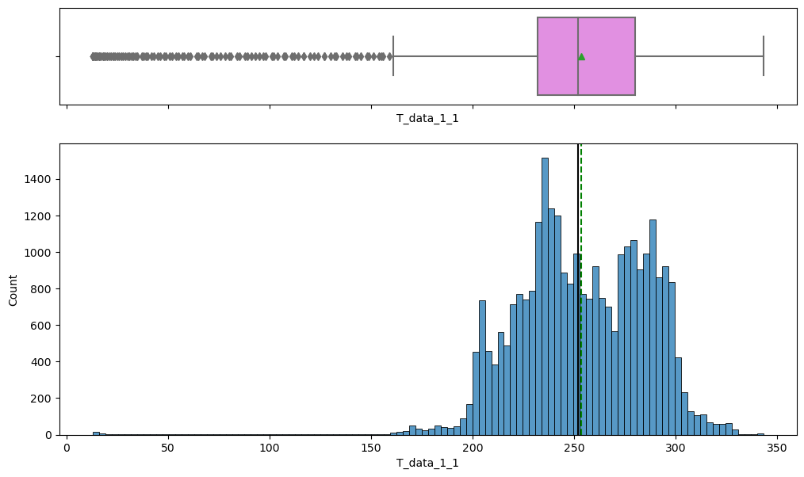

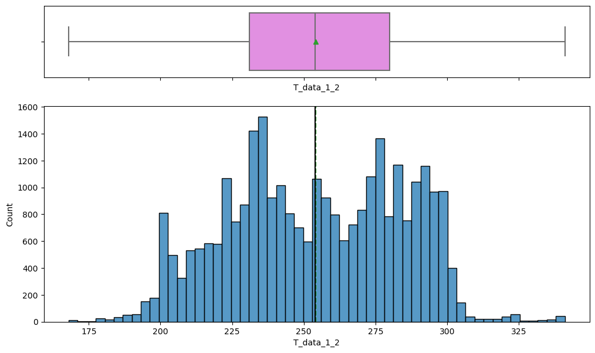

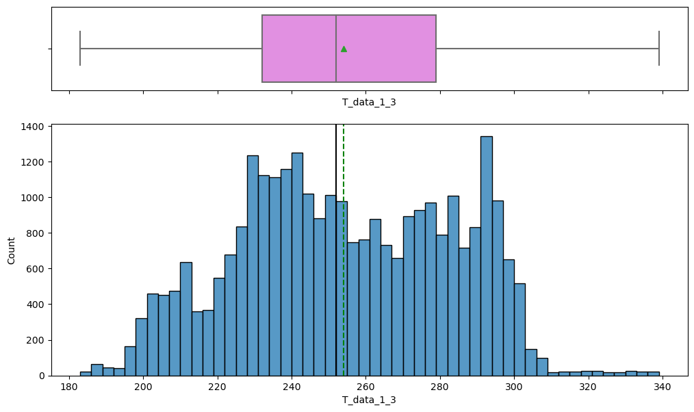

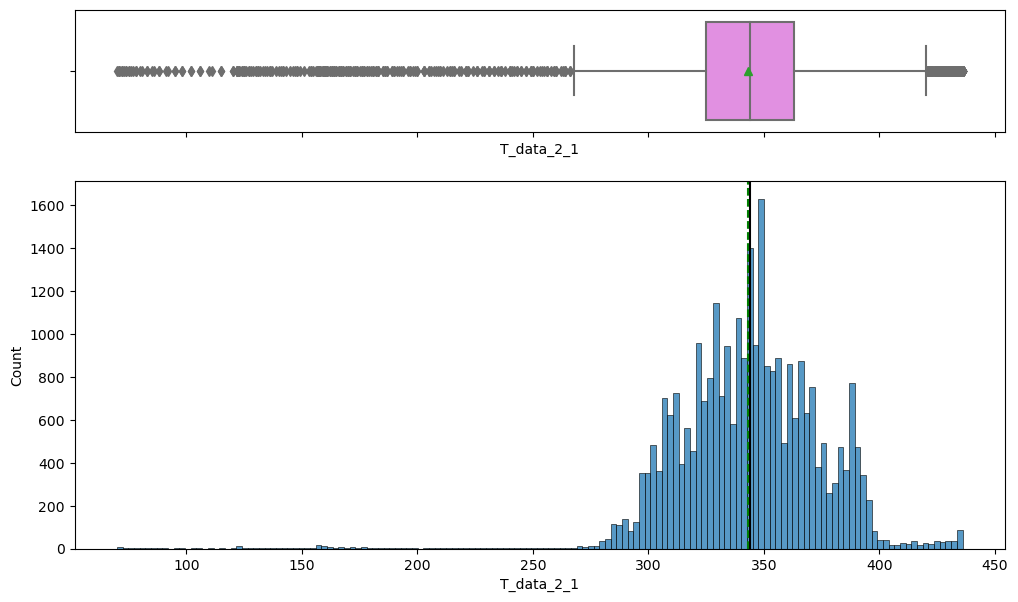

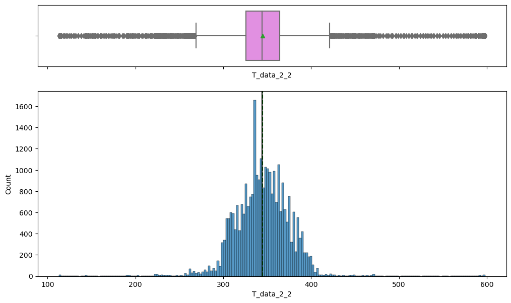

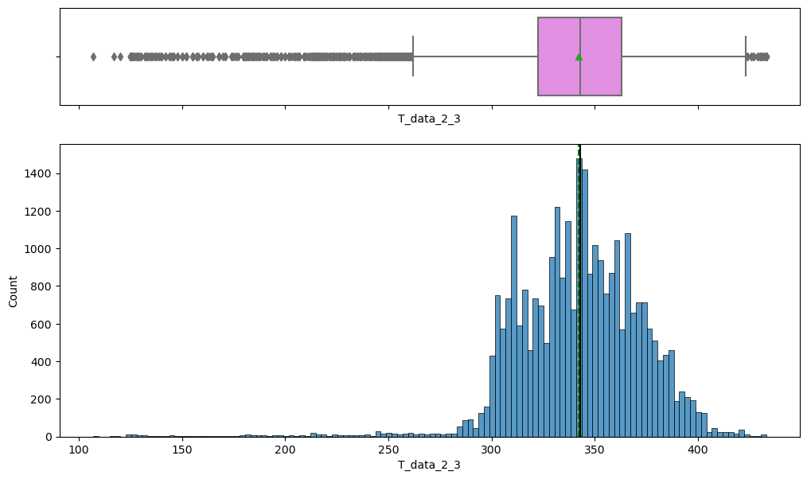

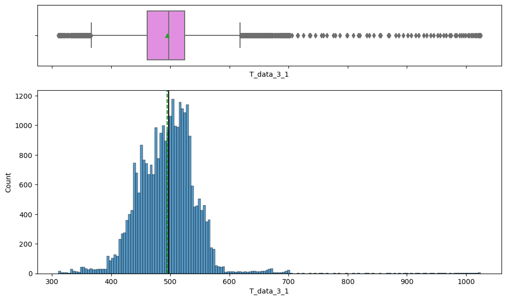

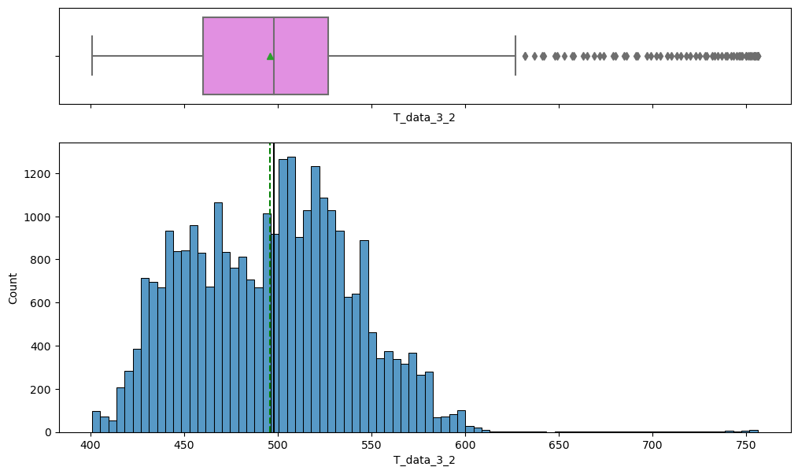

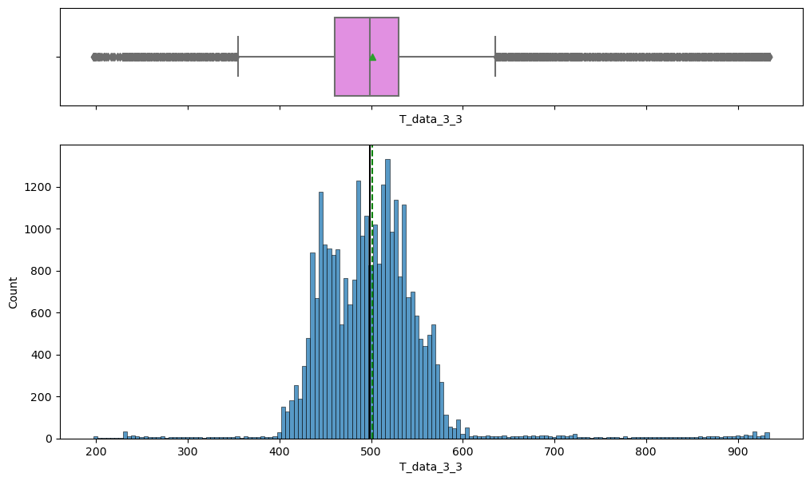

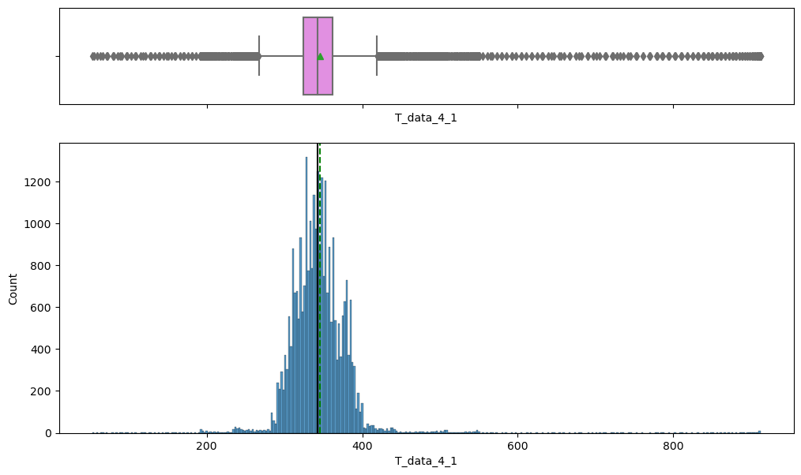

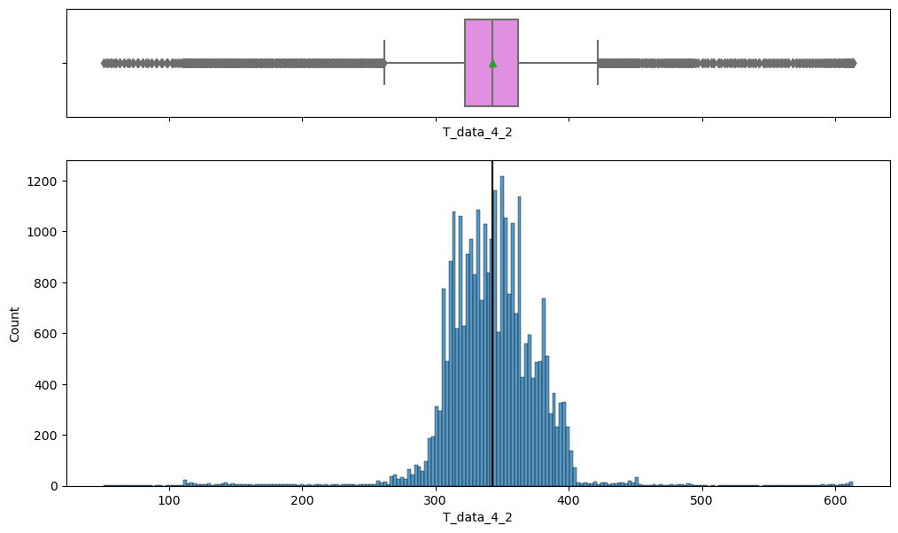

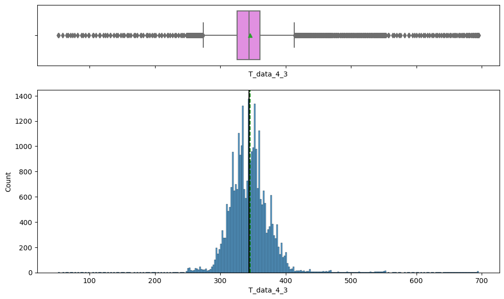

[6 more figures not shown]

```python
for feature in data.columns:
    histogram_boxplot(df, feature, figsize=(12,7), kde=False, bins=None)
```

- A few variables do not have outliers, while some variables have very minimal outliers
- For the boxplots with a huge number of temperatures that are outliers, they will not be treated as they might represent actual temperatures that the sensor picked up and they might be useful in helping the accuracy of the model

### Bivariate analysis

#### heatmap for correlations

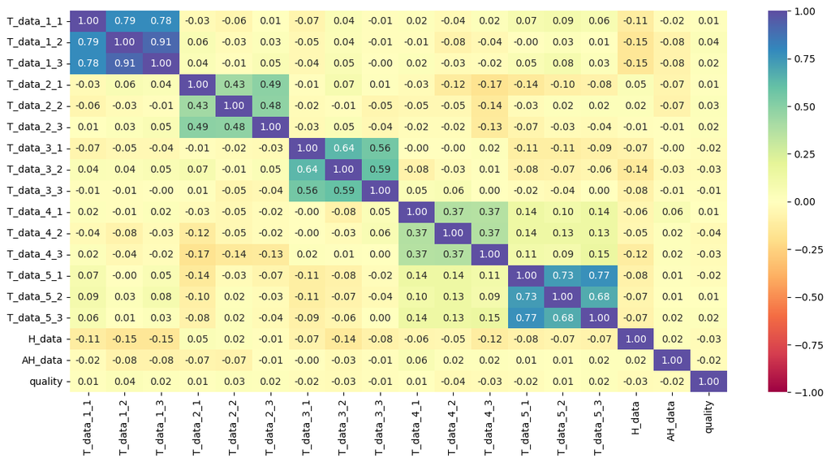

```python
#selecting numerical columns
num_col = df.select_dtypes(include=np.number).columns.tolist()
#heatmap for numerical columns
plt.figure(figsize=(15,7))
sns.heatmap(df[num_col].corr(), annot=True, vmin=-1, vmax=1, fmt=".2f", cmap="Spectral")
plt.show()
```

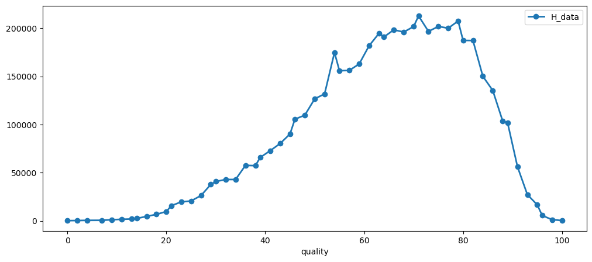

```python
pd.pivot_table(
                data=data,
                index=["quality"],
                values="H_data",
                aggfunc=np.sum,
).plot(kind="line",marker="o", linewidth=2, figsize=(12,5))
```

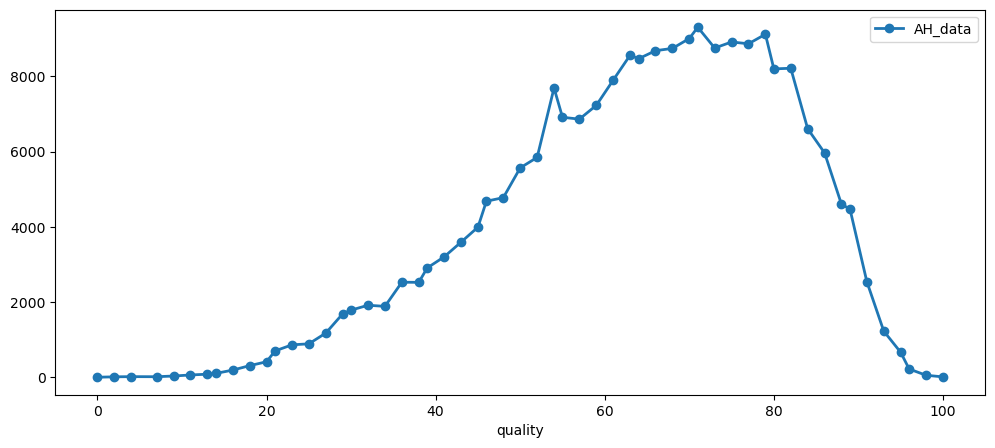

```python
pd.pivot_table(
                data=data,
                index=["quality"],
                values="AH_data",
                aggfunc=np.sum,
).plot(kind="line", marker="o", linewidth=2, figsize=(12,5))
```

## Data Pre-Processing

```python
data1=data.copy()
```

```python
#Seperating target variable and other variables
x=data1.drop(columns="quality")
Y=data1["quality"]
```

```python
#splitting data into training,validation,and test set:
#two parts, temporary and test

x_temp, x_test, Y_temp, Y_test = train_test_split(x,Y,test_size=0.2, random_state=1,shuffle=True)

#then we split the temprary set into train and validation

x_train, x_val, Y_train, Y_val = train_test_split(x_temp,Y_temp, test_size=0.25, random_state=1, stratify=Y_temp)
print(x_train.shape, x_val.shape, x_test.shape)
```

```
(17478, 17) (5826, 17) (5827, 17)
```

### Missing-Value treatment

#### Missing value imputation

```python
imputer=SimpleImputer(strategy="median")
```

```python
#fit and transform the train data
x_train=pd.DataFrame(imputer.fit_transform(x_train), columns=x_train.columns)

#transform the validation data
x_val=pd.DataFrame(imputer.transform(x_val), columns=x_train.columns)

#transform the test data
x_test=pd.DataFrame(imputer.transform(x_test), columns=x_train.columns)
```

```python
#checking that no column has missing values in train and test data
print(x_train.isna().sum())
print("-" * 30)
print(x_val.isna().sum())
print("-" * 30)
print(x_test.isna().sum())
```

```
T_data_1_1    0
T_data_1_2    0
T_data_1_3    0
T_data_2_1    0
T_data_2_2    0
T_data_2_3    0
T_data_3_1    0
T_data_3_2    0
T_data_3_3    0
T_data_4_1    0
T_data_4_2    0
T_data_4_3    0
T_data_5_1    0
T_data_5_2    0
T_data_5_3    0
H_data        0
AH_data       0
dtype: int64
------------------------------
T_data_1_1    0
T_data_1_2    0
T_data_1_3    0
T_data_2_1    0
T_data_2_2    0
T_data_2_3    0
T_data_3_1    0
T_data_3_2    0
T_data_3_3    0
T_data_4_1    0
T_data_4_2    0
T_data_4_3    0
T_data_5_1    0
T_data_5_2    0
T_data_5_3    0
H_data        0
AH_data       0
dtype: int64
------------------------------
T_data_1_1    0
T_data_1_2    0
T_data_1_3    0
T_data_2_1    0
T_data_2_2    0
T_data_2_3    0
T_data_3_1    0
T_data_3_2    0
T_data_3_3    0
T_data_4_1    0
T_data_4_2    0
T_data_4_3    0
T_data_5_1    0
T_data_5_2    0
T_data_5_3    0
H_data        0
AH_data       0
dtype: int64
```

- Missing values have all been imputed

## Model Building

**Let's create a function to calculate different metrics, so that we don't have to use the same code repeatedly for each model.**

```python
# function to compute adjusted R-squared
def adj_r2_score(predictors, targets, predictions):
    r2 = r2_score(targets, predictions)
    n = predictors.shape[0]
    k = predictors.shape[1]
    return 1 - ((1 - r2) * (n - 1) / (n - k - 1))


# function to compute different metrics to check performance of a regression model
def model_performance_regression(model, predictors, target):
    """
    Function to compute different metrics to check regression model performance

    model: regressor
    predictors: independent variables
    target: dependent variable
    """

    # predicting using the independent variables
    pred = model.predict(predictors)

    r2 = r2_score(target, pred)  # to compute R-squared
    adjr2 = adj_r2_score(predictors, target, pred)  # to compute adjusted R-squared
    rmse = np.sqrt(mean_squared_error(target, pred))  # to compute RMSE
    mae = mean_absolute_error(target, pred)  # to compute MAE

    # creating a dataframe of metrics
    df_perf = pd.DataFrame(
        {
            "RMSE": rmse,
            "MAE": mae,
            "R-squared": r2,
            "Adj. R-squared": adjr2,
        },
        index=[0],
    )

    return df_perf
```

**We are now done with pre-processing and evaluation criterion, so let's start building the model.**

### Decision Tree

```python
dtree = DecisionTreeRegressor(random_state=1)
dtree.fit(x_train, Y_train)
```

```
DecisionTreeRegressor(random_state=1)
```

```python
dtree_model_train_perf = model_performance_regression(dtree, x_train, Y_train)
print("Training performance \n",dtree_model_train_perf)
```

```
Training performance
    RMSE   MAE  R-squared  Adj. R-squared
0 0.000 0.000      1.000           1.000
```

```python
dtree_model_val_perf = model_performance_regression(dtree, x_val, Y_val)
print("Validation performance \n",dtree_model_val_perf)
```

```
Validation performance
    RMSE   MAE  R-squared  Adj. R-squared
0 7.610 5.246      0.785           0.784
```

- decision tree is overfitting the train data
- hyperparameter tuning needs to be done to improve performance

### Linear Regression

```python
Lr=lm.LinearRegression()
Lr.fit(x_train,Y_train)
```

```
LinearRegression()
```

```python
Lr_model_train_perf=model_performance_regression(Lr,x_train,Y_train)
print("Training performance \n",Lr_model_train_perf)
```

```
Training performance
     RMSE    MAE  R-squared  Adj. R-squared
0 16.327 13.308      0.012           0.011
```

```python
Lr_model_val_perf=model_performance_regression(Lr,x_val,Y_val)
print("Validation performance \n",Lr_model_val_perf)
```

```
Validation performance
     RMSE    MAE  R-squared  Adj. R-squared
0 16.340 13.314      0.008           0.005
```

- The Linear Regression model is overall bad, scores for both the training and testing data are bad, with the training model being very underfit and the accuracy with the validation set being dropped as a result

### Random Forest Model

```python
Rf_estimator=RandomForestRegressor(random_state=1)
Rf_estimator.fit(x_train,Y_train)
```

```
RandomForestRegressor(random_state=1)
```

```python
Rf_estimator_model_train_perf=model_performance_regression(Rf_estimator,x_train,Y_train)
print("Training performance \n", Rf_estimator_model_train_perf)
```

```
Training performance
    RMSE   MAE  R-squared  Adj. R-squared
0 2.057 1.524      0.984           0.984
```

```python
Rf_estimator_model_val_perf=model_performance_regression(Rf_estimator,x_val,Y_val)
print("Validation performance \n", Rf_estimator_model_val_perf)
```

```
Validation performance
    RMSE   MAE  R-squared  Adj. R-squared
0 5.426 4.059      0.891           0.890
```

- the validation set is overfitting the testing data by a small percentage, as shown by the drop in the validation performance, the model is not able to generate well on new information

### Bagging Model

```python
Bagging_estimator=BaggingRegressor(random_state=1)
Bagging_estimator.fit(x_train,Y_train)
```

```
BaggingRegressor(random_state=1)
```

```python
Bagging_estimator_model_train_perf=model_performance_regression(Bagging_estimator,x_train,Y_train)
print("Training performance \n",Bagging_estimator_model_train_perf)
```

```
Training performance
    RMSE   MAE  R-squared  Adj. R-squared
0 2.668 1.841      0.974           0.974
```

```python
Bagging_estimator_model_val_perf=model_performance_regression(Bagging_estimator,x_val,Y_val)
print("Validation performance \n",Bagging_estimator_model_val_perf)
```

```
Validation performance
    RMSE   MAE  R-squared  Adj. R-squared
0 5.977 4.450      0.867           0.867
```

- The huge drop in the r2 squared score between the training and the testing indicates that the bagging model has overfitted the training data and as a result the validation set isnt able to generate well

### Adaboost Regressor

```python
ab_regressor=AdaBoostRegressor(random_state=1)
ab_regressor.fit(x_train,Y_train)
```

```
AdaBoostRegressor(random_state=1)
```

```python
ab_regressor_model_train_perf=model_performance_regression(ab_regressor, x_train,Y_train)
print("Training performance \n",ab_regressor_model_train_perf)
```

```
Training performance
     RMSE    MAE  R-squared  Adj. R-squared
0 16.471 13.758     -0.006          -0.007
```

```python
ab_regressor_model_val_perf=model_performance_regression(ab_regressor,x_val,Y_val)
print("Validation performance \n",ab_regressor_model_val_perf)
```

```
Validation performance
     RMSE    MAE  R-squared  Adj. R-squared
0 16.522 13.790     -0.014          -0.017
```

- Both testing and validation sets are very low in terms of their r2 score
- hyperparameter tuning is not likely to fix the score associated with the model by a significant amount because the r2 scores are in the negative which is too low

### Gradient Boosting Regressor

```python
gb_estimator=GradientBoostingRegressor(random_state=1)
gb_estimator.fit(x_train,Y_train)
```

```
GradientBoostingRegressor(random_state=1)
```

```python
gb_estimator_model_train_performance=model_performance_regression(gb_estimator,x_train,Y_train)
print("Training performance \n",gb_estimator_model_train_performance)
```

```
Training performance
     RMSE    MAE  R-squared  Adj. R-squared
0 14.848 12.091      0.183           0.182
```

```python
gb_estimator_model_val_performance=model_performance_regression(gb_estimator,x_val,Y_val)
print("Validation performance \n",gb_estimator_model_val_performance)
```

```
Validation performance
     RMSE    MAE  R-squared  Adj. R-squared
0 15.109 12.298      0.152           0.150
```

- Training and testing r2 scores for the gradient boosting model are both too low, model is heavily underfit on the training dataset

### Model Performance comparison

**After looking at performance of all the models, let's decide which models can further improve with hyperparameter tuning.**

**Note**: You can choose to tune some other model if XGBoost gives error.

## Hyperparameter Tuning

**Hyperparameter tuning can take a long time to run, so to avoid that time complexity - you can use the following grids, wherever required.**

- For Bagging :

param_grid = { 'max_samples': [0.7,0.8,0.9,1], 'max_features': [0.7,0.8,0.9,1], 'n_estimators' : [50, 100, 120, 150], }

- For Random Forest:

param_grid = { 'max_depth':[4, 6, 8, 10, None], 'max_features': ['sqrt','log2',None], 'n_estimators': [80, 90, 100, 110, 120] }

- For Decision Trees:

param_grid = { 'max_depth': list(np.arange(15,20)) + [None], 'min_samples_leaf': [1, 3] + [None], 'max_leaf_nodes' : [5, 10, 15] + [None], 'min_impurity_decrease': [0.001, 0.0] }

### Decision Tree

```python
#type of regressor
dtree_tuned=DecisionTreeRegressor(random_state=1)

#Grid of parameters to choose from
param_grid = {
    'max_depth': list(np.arange(15,20)) + [None],
    'min_samples_leaf': [1, 3] + [None],
    'max_leaf_nodes' : [5, 10, 15] + [None],
    'min_impurity_decrease': [0.001, 0.0]
}

#Type of scoring used to combine parameter combinations
scorer=metrics.make_scorer(metrics.r2_score)

#Run the grid search
grid_obj=GridSearchCV(dtree_tuned,param_grid,scoring=scorer,cv=5)
grid_obj=grid_obj.fit(x_train,Y_train)

#set the clf to the best combination of parameters
dtree_tuned=grid_obj.best_estimator_

#Fit the best algorithm to the data
dtree_tuned.fit(x_train,Y_train)
```

```
DecisionTreeRegressor(random_state=1)
```

```python
dtree_tuned_model_train_perf=model_performance_regression(dtree_tuned, x_train, Y_train)
print("Training performance \n",dtree_tuned_model_train_perf)
```

```
Training performance
    RMSE   MAE  R-squared  Adj. R-squared
0 0.000 0.000      1.000           1.000
```

```python
dtree_tuned_model_val_perf=model_performance_regression(dtree_tuned,x_val,Y_val)
print("Validation performance \n",dtree_tuned_model_val_perf)
```

```
Validation performance
    RMSE   MAE  R-squared  Adj. R-squared
0 7.610 5.246      0.785           0.784
```

- No change in the decision tree model in terms of r2 squared, the model is still having trouble generalizing the validation set even with the hyperparameter tuning

```python
#importance of features in tree building
print(pd.DataFrame(dtree_tuned.feature_importances_,columns=["Imp"], index=x_train.columns).sort_values(by = "Imp", ascending=False))
```

```
             Imp
T_data_3_2 0.086
T_data_3_1 0.081
T_data_2_3 0.072
T_data_3_3 0.068
T_data_4_1 0.066
T_data_4_2 0.065
T_data_2_1 0.062
T_data_5_1 0.060
T_data_5_3 0.058
T_data_5_2 0.057
T_data_2_2 0.056
T_data_4_3 0.056
T_data_1_1 0.052
T_data_1_2 0.046
T_data_1_3 0.043
H_data     0.040
AH_data    0.031
```

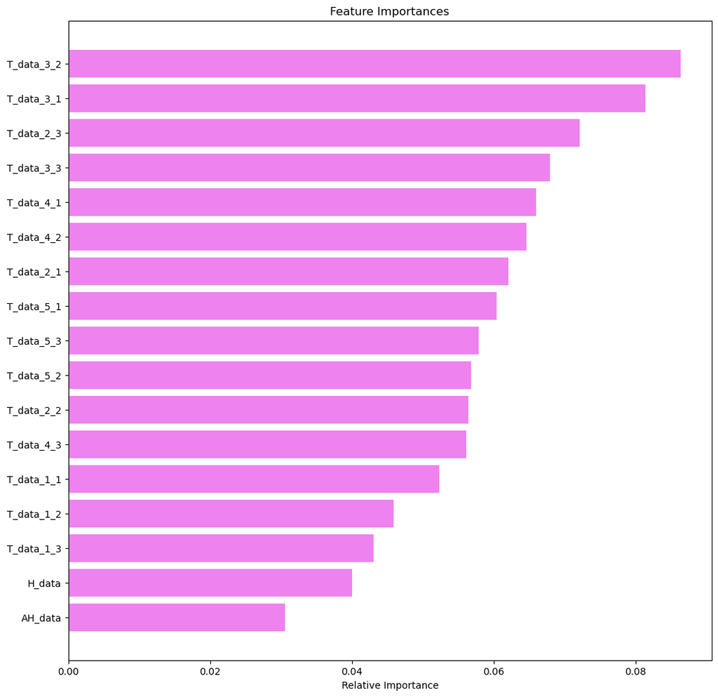

```python
feature_names=x_train.columns
importances=dtree_tuned.feature_importances_
indices=np.argsort(importances)

plt.figure(figsize=(12,12))
plt.title('Feature Importances')
plt.barh(range(len(indices)), importances[indices],color='violet',align='center')
plt.yticks(range(len(indices)), [feature_names[i] for i in indices])
plt.xlabel('Relative Importance')
plt.show()
```

- T_data_3_2 has the highest importance in the decision tree model followed by T_data_3_1 and T_data_2_3

### Random Forest Model

```python
%%time

Rf_tuned = RandomForestRegressor(random_state=1)

# Grid of parameters to choose from
parameters = {
                'max_depth':[4, 6, 8, 10, None],
                'max_features': ['sqrt','log2',None],
                'n_estimators': [80, 90, 100, 110, 120]
}

# Type of scoring used to compare parameter combinations
scorer = metrics.make_scorer(metrics.r2_score)

# Run the grid search
Randomized_cv = RandomizedSearchCV(Rf_tuned, parameters, scoring=scorer, n_iter=40, n_jobs = -1, cv=5, random_state=1)
Randomized_cv = Randomized_cv.fit(x_train, Y_train)

# Set the clf to the best combination of parameters
Rf_tuned = Randomized_cv.best_estimator_

# Fit the best algorithm to the data.
Rf_tuned.fit(x_train, Y_train)
```

```
CPU times: total: 8.42 s
Wall time: 1min 1s
```

```
RandomForestRegressor(max_features='log2', n_estimators=110, random_state=1)
```

```python
Rf_tuned_model_train_perf=model_performance_regression(Rf_tuned,x_train,Y_train)
print("Training performance \n",Rf_tuned_model_train_perf)
```

```
Training performance
    RMSE   MAE  R-squared  Adj. R-squared
0 1.940 1.435      0.986           0.986
```

```python
Rf_tuned_model_val_perf=model_performance_regression(Rf_tuned,x_val,Y_val)
print("Validation performance \n",Rf_tuned_model_val_perf)
```

```
Validation performance
    RMSE   MAE  R-squared  Adj. R-squared
0 5.133 3.822      0.902           0.902
```

- although r2 scores have increased in both models after the tuning, the problem of overfitting still has not been solved as drop between the testing and validation set is still there

```python
#importance of features in tree building
print(pd.DataFrame(Rf_tuned.feature_importances_,columns = ["Imp"], index=x_train.columns).sort_values(by='Imp',ascending=False))
```

```
             Imp
T_data_3_1 0.073
T_data_3_2 0.072
T_data_2_3 0.066
T_data_4_1 0.066
T_data_3_3 0.065
T_data_4_2 0.064
T_data_2_1 0.062
T_data_4_3 0.060
T_data_5_3 0.059
T_data_2_2 0.058
T_data_1_3 0.058
T_data_1_1 0.056
T_data_5_2 0.055
T_data_1_2 0.054
T_data_5_1 0.053
H_data     0.044
AH_data    0.036
```

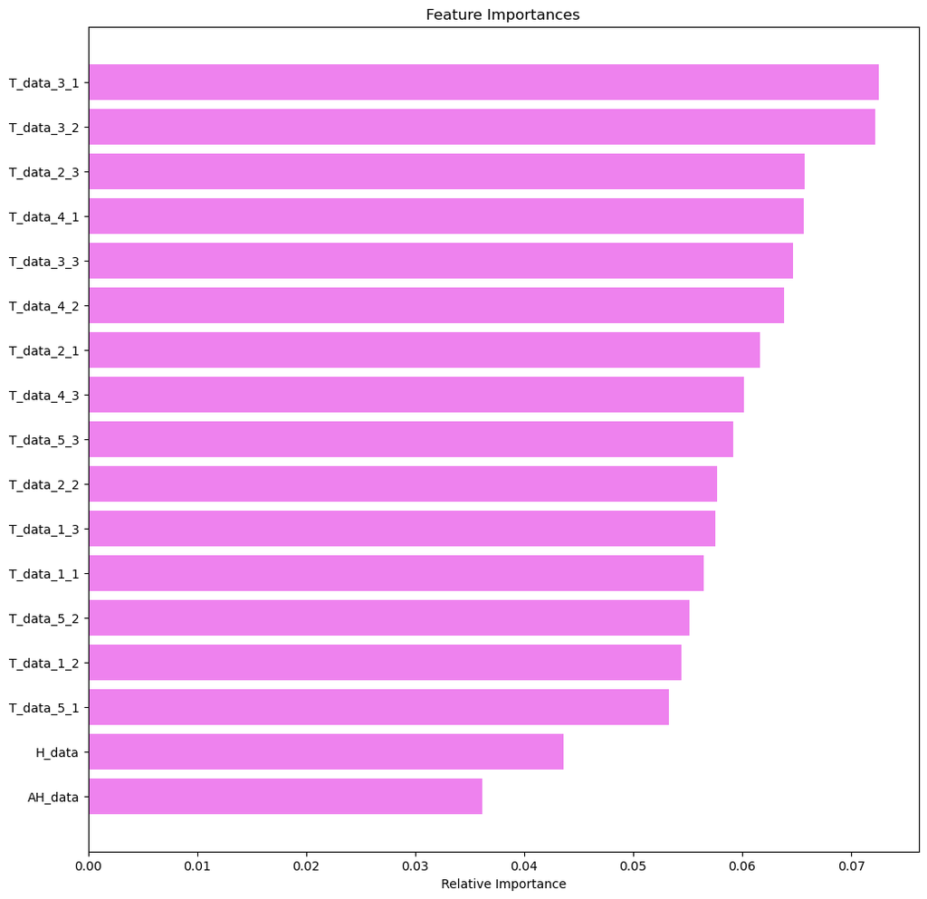

```python
feature_names=x_train.columns
importances=Rf_tuned.feature_importances_
indices=np.argsort(importances)

plt.figure(figsize=(12,12))
plt.title('Feature Importances')
plt.barh(range(len(indices)), importances[indices], color='violet',align='center')
plt.yticks(range(len(indices)),[feature_names[i] for i in indices])
plt.xlabel('Relative Importance')
plt.show()
```

- T_data_3_1 has the highest amount of importance when it comes to when it comes to the random forest with T_data_3_2 and T_Data_2_3 trailing behind in 2nd and 3rd,respectively

### Bagging

```python
#type of regressor
Bagging_tuned=BaggingRegressor(random_state=1)

#Grid of param_grid

param_grid = {
                'max_samples': [0.7,0.8,0.9,1],
                'max_features': [0.7,0.8,0.9,1],
                'n_estimators' : [50, 100, 120, 150]
}


#type of scoring used to compare parameter combinations
scorer=metrics.make_scorer(metrics.r2_score)

#Run the grid search
grid_obj=GridSearchCV(Bagging_tuned, param_grid, scoring=scorer,cv=5)
grid_obj=grid_obj.fit(x_train,Y_train)

#set the clf to the best combination of parameters
Bagging_tuned=grid_obj.best_estimator_

#Fit the best algorithm to the data
Bagging_tuned.fit(x_train,Y_train)
```

```python
Bagging_tuned_model_test_perf=model_performance_regression(Bagging_tuned,x_train,Y_train)
print("Training performance: \n",Bagging_tuned_model_test_perf)
```

```
Training performance:
    RMSE   MAE  R-squared  Adj. R-squared
0 2.248 1.681      0.981           0.981
```

```python
Bagging_tuned_model_val_perf=model_performance_regression(Bagging_tuned,x_val,Y_val)
print("Testing performance: \n",Bagging_tuned_model_val_perf)
```

```
Testing performance:
    RMSE   MAE  R-squared  Adj. R-squared
0 5.395 4.057      0.892           0.892
```

**We have now tuned all the models, let's compare the performance of all tuned models and see which one is the best.**

## Model performance comparison and choosing the final model

```python
models_train_comp_df=pd.concat([dtree_model_train_perf.T, dtree_tuned_model_train_perf.T, Lr_model_train_perf.T,Rf_estimator_model_train_perf.T,Rf_tuned_model_train_perf.T,Bagging_estimator_model_train_perf.T,Bagging_tuned_model_test_perf.T,ab_regressor_model_train_perf.T,gb_estimator_model_train_performance.T],axis=1)
models_train_comp_df.columns = ["decision tree model","Tuned decision tree model","Linear Regression Model","Random Forest Model","Tuned Random Forest Model", "Bagging Model","Tuned Bagging model","adaboost regressor model","gradient boost model",]
print("Training performance comparison:")
models_train_comp_df
```

[output not shown]